# Basics

Anna Hutchinson

23/08/2019

### Definitions

**Tissue: An essemble of similar cells and their extracellular matrix (organisational level between an organ and a cell).**

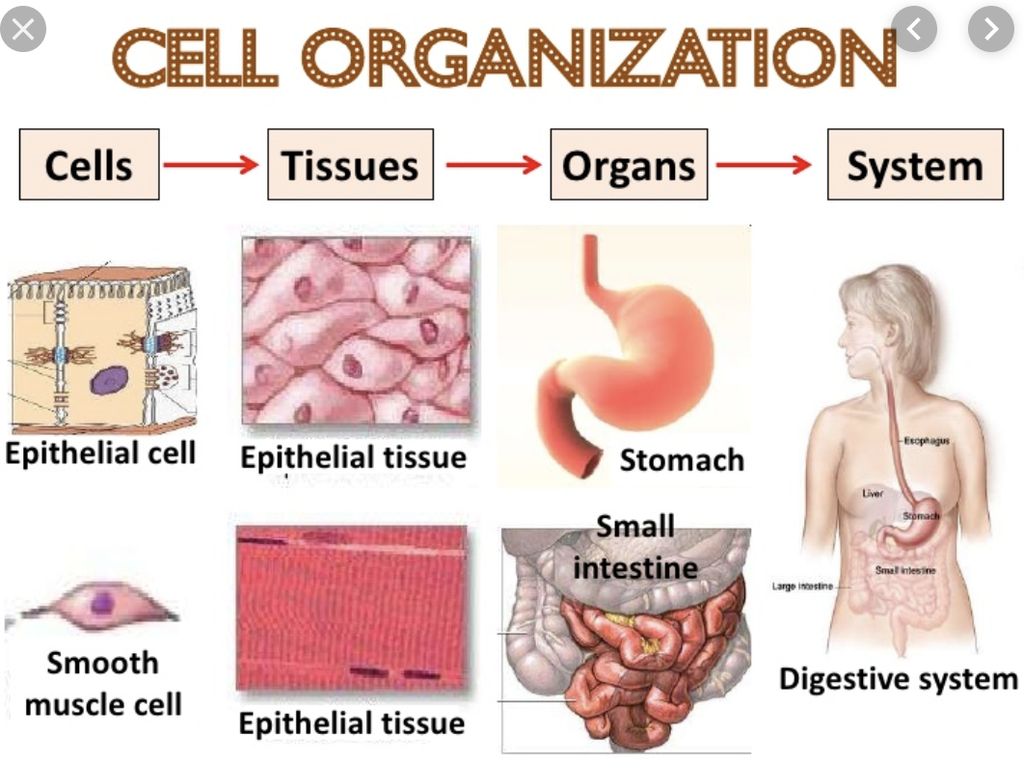

**Enhancers are associated with chromatin modifications that are distinct epigenetic features in a tissue-specific manner.**

- Once you’ve identified a genetic variant you need to see what gene that variant is effecting and in what tissue type. E.g. the T2D-associated genetic variant may lie within an active enhancer in pancreatic islets (regions of the pancreas containing hormone-producing cells) [^1] [^2]
- Note only ~0.1% of the genome is variable (just 3 million bases).

**Pathophysiology: In this context, how a mutation affects protein function which affects disease.**

**Additive genetic effects: Two or more genes source a single contribution to the final phenotype or two alleles of a single gene (in a heterozygote) combine so that their combined effects equal the sum of their individual effects.**

**Non-additive genetic effects: Examples include dominance (of alleles at a single locus) or epistasis (effect of a gene is dependent on other genes, e.g. effect of one gene is suppressed/masked by a different gene).**

#### UK biobank

- Started recruiting patients in 2006.
- Data on 500,000 individuals (imaging/ genotype/ whole exome sequencing/ blood etc).
- Currently conducing whole genome sequencing on 50,000 individuals, then hope to do all 500,000.

#### UK10K

- Started in 2008.
- For rare genetic variants.
- Generate whole genome and exome sequence data for almost 10,000 highly phenotyped individuals.
- Hopes to be able to detect variants with allele frequencies as low as 0.1%!

#### 100,000 Genomes Project

- Started in 2012/13.
- Sequenced 100,000 genomes from 85,000 people with rare diseases or cancer and their families.

#### GTEx

- Investigate variation in gene expression across people.
- Samples from 53 non-diseased tissues from 1000 people.
- Help to identify what tissues and genes genetic variants are effecting.

#### ENCODE

- Encyclopedia of DNA elements.
- Develop a list of functional elements in the human genome, including regulatory elements.

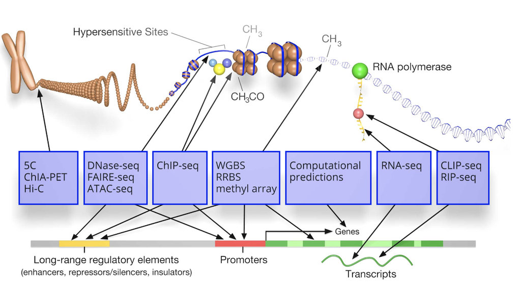

[^1]: https://www.ncbi.nlm.nih.gov/pubmed/24413736
[^2]: https://www.pnas.org/content/110/44/17921